# Reproducible Research: Peer Assessment 1

## Loading and preprocessing the data

```r
getwd()
```

```
## [1] "C:/Users/Diandian/Documents/self_education/Working-directory/repdata_data_activity"
```

```r
setwd("C:/Users/Diandian/Documents/self_education/Working-directory/repdata_data_activity")
activity <- read.csv("./activity.csv")
```

## What is mean total number of steps taken per day?

1.Extract the weekdays of the dates

```r
activity$weekdays <- weekdays(as.Date(activity[,2]))
```

2.Calculate the total number of steps taken perday

```r
totalstep_perday <- tapply(activity$steps,activity$date,sum)
Tstep_perday <- cbind(names(totalstep_perday),totalstep_perday)
Tstep_perday <- as.data.frame(Tstep_perday)
row.names(Tstep_perday) <- seq_len(nrow(Tstep_perday))
colnames(Tstep_perday) <- c("dates","Tstep")
Tstep_perday$Tstep <- as.numeric(as.character(Tstep_perday$Tstep))
```

3.Make a histogram of the total number of steps taken each day

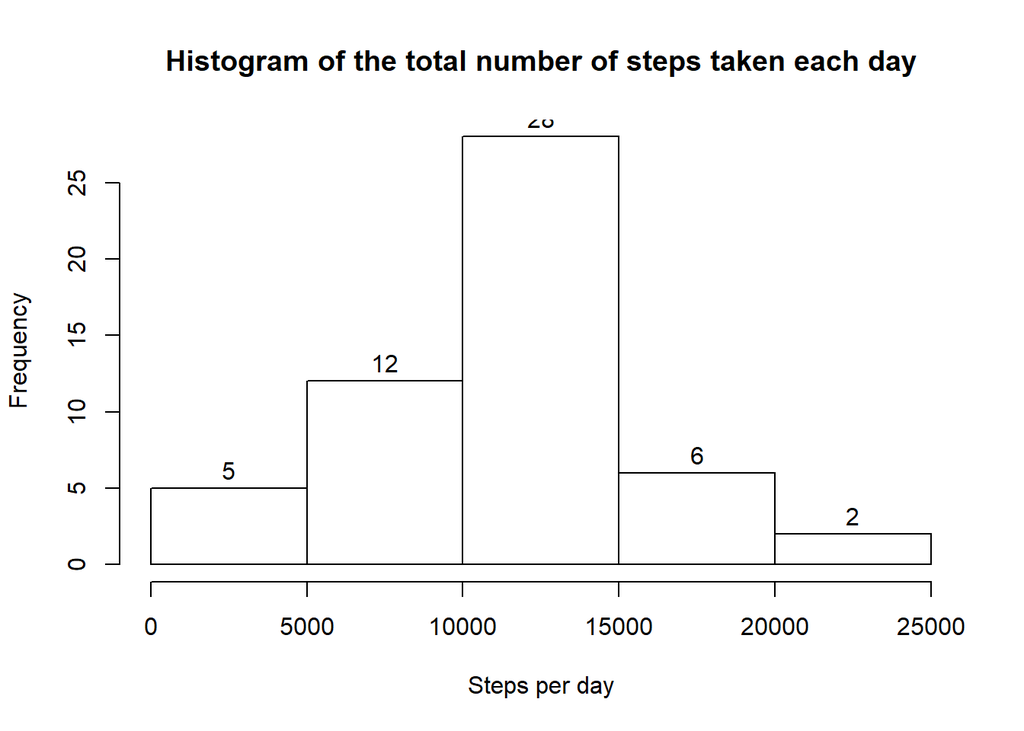

```r
hist(Tstep_perday$Tstep,xlab="Steps per day",main = "Histogram of the total number of steps taken each day", labels = TRUE)
```

4.Report the mean and median of the total number of steps taken per day

```r
summary(Tstep_perday$Tstep)
```

```
##    Min. 1st Qu.  Median    Mean 3rd Qu.    Max.    NA's
##      41    8841   10765   10766   13294   21194       8
```

## What is the average daily activity pattern?

1.Make a time series plot and the average number of steps taken

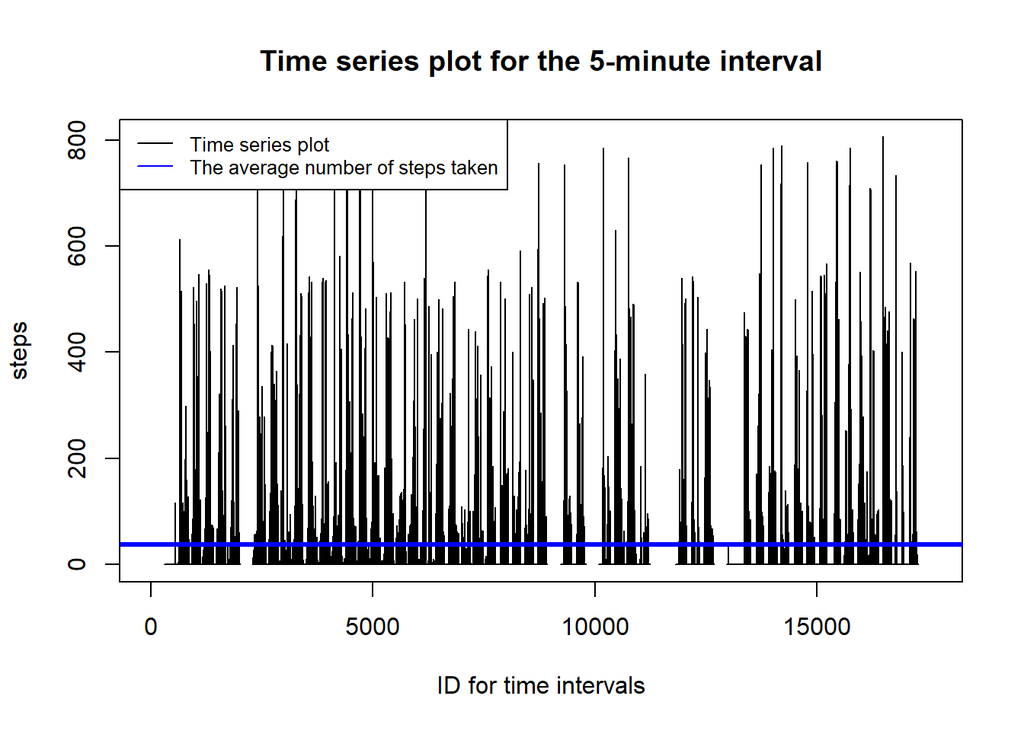

```r
plot(activity$steps,type = "l",xlab="ID for time intervals",ylab="steps",main = "Time series plot for the 5-minute interval")
abline(h=mean(activity$steps,na.rm = TRUE),col="blue",lwd=3)
legend("topleft", legend=c("Time series plot", "The average number of steps taken"),
       col=c("black", "blue"), lty=1:1, cex=0.8)
```

2.Determine which 5-minute interval contains teh maximum number of steps

```r
activity[which.max(activity$steps),]
```

```
##       steps       date interval weekdays
## 16492   806 2012-11-27      615  Tuesday
```

## Imputing missing values

1.Calculate and report the total number of missing values in the dataset

```r
sum(is.na(activity$steps))
```

```
## [1] 2304
```

2.Fill in the missing data with 0

```r
activity_nona <- activity
activity_nona[is.na(activity_nona)] <- 0
```

3.Repeat what we did to get the number of steps per day and report the summary figure

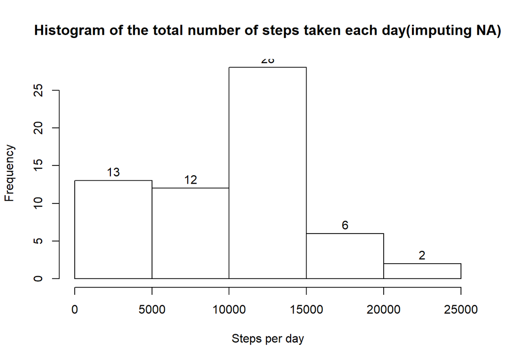

```r
totalstep_perday_2 <- tapply(activity_nona$steps,activity_nona$date,sum)
Tstep_perday_2 <- cbind(names(totalstep_perday_2),totalstep_perday_2)
Tstep_perday_2 <- as.data.frame(Tstep_perday_2)
row.names(Tstep_perday_2) <- seq_len(nrow(Tstep_perday_2))
colnames(Tstep_perday_2) <- c("dates","Tstep")
Tstep_perday_2$Tstep <- as.numeric(as.character(Tstep_perday_2$Tstep))

hist(Tstep_perday_2$Tstep,xlab="Steps per day",main = "Histogram of the total number of steps taken each day(imputing NA)", labels = TRUE)
```

```r
summary(Tstep_perday_2$Tstep)
```

```
##    Min. 1st Qu.  Median    Mean 3rd Qu.    Max.
##       0    6778   10395    9354   12811   21194
```

4.Results are different. Treat NA as 0 substantially decreased the median and the mean of the daily number of the steps.

## Are there differences in activity patterns between weekdays and weekends?

1.Create a new factor variable in the dataset with two levels - “weekday” and “weekend”

```r
activity_nona$weekday_class <- ifelse(activity_nona$weekdays %in% c("Saturday","Sunday"),"weekend","weekday")
```

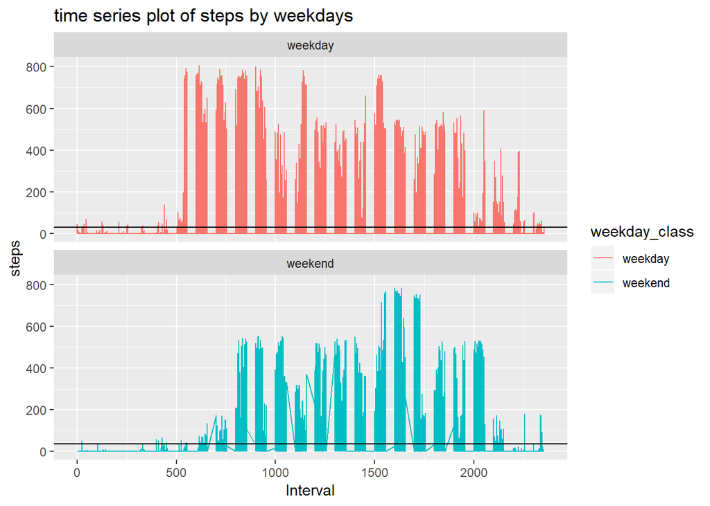

```r
library(ggplot2)
Average <- tapply(activity_nona$steps,activity_nona$weekday_class,mean)
AverageData <- as.data.frame(cbind(names(Average),Average))
colnames(AverageData) <- c("weekday_class","Average")
plot<- ggplot(activity_nona, aes(x = interval , y = steps, color = weekday_class)) +
    geom_line() +
    labs(title = "time series plot of steps by weekdays", x = "Interval", y = "steps") +
    facet_wrap(~weekday_class, ncol = 1, nrow=2)+
    geom_hline(data = AverageData, aes(yintercept = as.numeric(as.character(AverageData$Average))))
print(plot)
```